# COMIX: Coarsened mixtures of hierarchical skew normal kernels

S. Gorsky, C. Chan and L. Ma

# Fitting the COMIX algorithm to multi-sample data

In the following, we provide an application-oriented overview of COMIX and its main parameters through a demonstration of the COMIX code and its various utility and diagnostic functions. The presentation will provide guidelines for choosing the main parameters of interest and assessing the convergence of the MCMC chain.

We start by fitting the model to data that are simulated from 5 clusters in 3 dimensions that are not aligned across 4 samples. The clusters are drawn from a multivariate skew normal distribution.

```r
# Number of clusters:
K <- 5
k_names <- paste0("Cluster", 1:K)
# Number of samples:
J <- 4
j_names <- paste0("Sample", 1:J)
# Dimension:
p <- 3
p_names <- paste0("p", 1:p)
# For the sake of the demonstration, we will generate three large clusters (1, 2 and 3)
# and two smaller clusters (4 and 5):

n_jk <-
  matrix(
    c(
      200, 210, 290, 30, 40,     # First row for the five clusters of the first sample
      220, 190, 340,  0, 50,     # Second row for the five clusters of the second sample
        0, 180, 340, 60, 60,     # Third row for the five clusters of the third sample
      150, 240, 310, 50, 40      # Fourth row for the five clusters of the fourth sample
      ),
    byrow = TRUE,
    nrow = 4,                    # Number of samples
    ncol = 5,                    # Number of clusters
    dimnames = list(j_names, k_names)
    )

print(n_jk)
```

```
##         Cluster1 Cluster2 Cluster3 Cluster4 Cluster5
## Sample1      200      210      290       30       40
## Sample2      220      190      340        0       50
## Sample3        0      180      340       60       60
## Sample4      150      240      310       50       40
```

Note that the first cluster is absent from the third sample and the fourth cluster absent from the second sample.

Thus, the total number of observations is:

```r
(n <- sum(n_jk))
```

```
## [1] 3000
```

Next, we sample parameters for the different clusters and samples in a fashion similar to that of the generative model of COMIX. The model assumes that cluster locations for each sample are drawn from a multivariate normal distribution around a “grand” cluster location. We denote this parameter as $\xi_{0,k}$, a single $\xi_0$ parameter for each cluster $k$. Here, there are 5 grand cluster locations, $\xi_{0,1},...,\xi_{0,5}$, one for each cluster. These too are drawn from a multivariate normal distribution, which we center at $b_0=(0,0,0)$ and set the variance-covariance matrix $B_0$, set to be $8\cdot I$:

```r
set.seed(1)
b0 <- rep(0, p)
B0 <- 8 * diag(p)
xi0 <- t(MASS::mvrnorm(K, b0, B0))
colnames(xi0) <- paste0("xi0,", 1:K)
rownames(xi0) <- p_names

print(xi0)
```

```
##        xi0,1     xi0,2     xi0,3     xi0,4      xi0,5
## p1  4.275963 1.1026432 -1.757134 -6.264117  3.1817851
## p2 -2.320635 1.3786576  2.088298  1.628556 -0.8637688
## p3 -1.771879 0.5194218 -2.363515  4.512135  0.9319887
```

`xi0` is a $3\times5$ matrix, where each of the 5 columns for the 5 clusters is a point in a 3-dimensional space.

The variance-covariance matrix, that alongside $\xi0$ paramaterizes the multivariate normal distribution of cluster locations around the grand locations, denoted by $E_k$ (one for each of the 5 clusters) determines the amount of misalignment between clusters. For the sake of the example, we’ll set clusters 2 and 5 to have larger misalignment, and clusters 1, 3 and 4 to be very nearly aligned. This can be done in the following manner:

```r
E <- list()

# The 3 well aligned clusters:
E[[1]] <- 0.001 * diag(p)
E[[3]] <- 0.001 * diag(p)
E[[4]] <- 0.001 * diag(p)

# The 2 misaligned clusters:
E[[2]] <- 0.25 * diag(p)
E[[5]] <- 0.25 * diag(p)

names(E) <- paste0("E", 1:K)
E <- lapply(E, function(e) {rownames(e) <- p_names; colnames(e) <- p_names; e})
```

So, for example, the variance-covariance matrix for the first cluster is:

```r
print(E[1])
```

```
## $E1
##       p1    p2    p3
## p1 0.001 0.000 0.000
## p2 0.000 0.001 0.000
## p3 0.000 0.000 0.001
```

Based on the parameters $\xi_{0,k}$ and `E_k` we can draw location parameters $\xi_{j,k}$ for each sample and cluster (every element of the following list corresponds to a single cluster with 4 values of `xi` of dimension 3):

```r
xi <- NULL
for (k in 1:K) {
  xi <-
    bind_rows(
      xi,
      bind_cols(
        expand_grid(Sample = 1:J, Cluster = k),
        as_tibble(MASS::mvrnorm(J, xi0[ , k], E[[k]]))
        )
      )
}
```

And so we can see, for example, that the first cluster has location parameters that are nearly equal across all samples:

```r
xi %>% filter(Cluster == 1)
```

```
## # A tibble: 4 × 5
##   Sample Cluster    p1    p2    p3
##    <int>   <int> <dbl> <dbl> <dbl>
## 1      1       1  4.21 -2.30 -1.77
## 2      2       1  4.30 -2.29 -1.77
## 3      3       1  4.27 -2.30 -1.74
## 4      4       1  4.27 -2.32 -1.75
```

And the second cluster has location parameters that differ much more between samples:

```r
xi %>% filter(Cluster == 2)
```

```
## # A tibble: 4 × 5
##   Sample Cluster    p1    p2     p3
##    <int>   <int> <dbl> <dbl>  <dbl>
## 1      1       2 0.895 1.33  -0.216
## 2      2       2 0.905 1.57   0.280
## 3      3       2 1.07  1.35   0.728
## 4      4       2 1.65  0.690  1.20
```

In addition to a location parameter, each multivariate skew normal cluster is also paramaterized with a scale $p\times p$ matrix parameter $\Sigma_k$, and a skewness vector $\alpha_k$ of length $p$.

Let’s choose some random scale parameters for the different clusters:

```r
Sigma <- list()

for (k in 1:K) {
  Sigma[[k]] <- matrix(0.1, p, p) + diag(0.2, p, p)
  tmp <- rep(0, p)
  tmp[sample(1:p, 1)] <- 0.1
  Sigma[[k]] <- Sigma[[k]] + diag(tmp)
}
```

Set clusters 1 and 2 and 5 with no skewness, and clusters 3 and 4 with heavy skewness in one of the margins:

```r
alpha <- matrix(0, nrow = p, ncol = K, dimnames = list(p_names, k_names))

# First margin of the skewness vector of third cluster:
alpha[1, 3] <- 5
# Second margin of the skewness vector of fourth cluster:
alpha[2, 4] <- -6

print(alpha)
```

```
##    Cluster1 Cluster2 Cluster3 Cluster4 Cluster5
## p1        0        0        5        0        0
## p2        0        0        0       -6        0
## p3        0        0        0        0        0
```

```r
psi_G <- list()
for (k in 1:K) {
  psi_G[[k]] <- COMIX::transform_params(Sigma[[k]], alpha[ , k])
}
```

Note that when $\alpha_k = 0_p$, $\psi_k$ is also $0_p$, in which case $G_k=\Sigma_k$:

```r
psi_G[[1]]$G
```

```
##      [,1] [,2] [,3]
## [1,]  0.3  0.1  0.1
## [2,]  0.1  0.4  0.1
## [3,]  0.1  0.1  0.3
```

```r
Sigma[[1]]
```

```
##      [,1] [,2] [,3]
## [1,]  0.3  0.1  0.1
## [2,]  0.1  0.4  0.1
## [3,]  0.1  0.1  0.3
```

But when $\alpha_k(i) \ne 0$ for some $i$, both parameters differ:

```r
psi_G[[3]]$psi
```

```
##           [,1]
## [1,] 0.5370862
## [2,] 0.1790287
## [3,] 0.1790287
```

```r
alpha[ , 3]
```

```
## p1 p2 p3
##  5  0  0
```

```r
psi_G[[3]]$G
```

```
##             [,1]        [,2]        [,3]
## [1,] 0.011538462 0.003846154 0.003846154
## [2,] 0.003846154 0.267948718 0.067948718
## [3,] 0.003846154 0.067948718 0.367948718
```

```r
Sigma[[3]]
```

```
##      [,1] [,2] [,3]
## [1,]  0.3  0.1  0.1
## [2,]  0.1  0.3  0.1
## [3,]  0.1  0.1  0.4
```

We are now ready to sample the 3000 multivariate skew normal data points into a $3000\times p$ matrix `Y`, and in addition generate an integer vector `C` of length 3000, denoting for each row of `Y` the sample from which the corresponding observation is drawn. As a sanity check, we also denote for each observation which cluster it was drawn from in a vector of length 3000 named `t`:

```r
Y <- NULL
C <- NULL
t <- NULL
for (j in 1:J) {
  for (k in 1:K) {
    xi_jk <- xi %>% filter(Sample == j, Cluster == k) %>% select(all_of(p_names)) %>% unlist()
    Y <-
      rbind(
        Y,
        sn::rmsn(n_jk[j, k], xi = xi_jk, Sigma[[k]], alpha = alpha[ , k])
      )
    C <- c(C, rep(j, n_jk[j, k]))
    t <- c(t, rep(k, n_jk[j, k]))
  }
}

# Sanity check:
print(table(C, t))
```

```
##    t
## C     1   2   3   4   5
##   1 200 210 290  30  40
##   2 220 190 340   0  50
##   3   0 180 340  60  60
##   4 150 240 310  50  40
```

```r
print(n_jk)
```

```
##         Cluster1 Cluster2 Cluster3 Cluster4 Cluster5
## Sample1      200      210      290       30       40
## Sample2      220      190      340        0       50
## Sample3        0      180      340       60       60
## Sample4      150      240      310       50       40
```

```r
print(all(table(C, t) == n_jk))
```

```
## [1] TRUE
```

```r
# Make tibbles and naming variables for plotting:
Y_tb <- Y
colnames(Y_tb) <- p_names
Y_tb <-
  bind_cols(
    tibble(Sample = factor(C), Cluster = factor(t)),
    as_tibble(Y_tb)
  )

xi0_tb <- as_tibble(t(xi0)) %>% mutate(Cluster = factor(1:K))

Cluster_names <- paste("Cluster", 1:K)
names(Cluster_names) <- 1:K

Sample_names <- paste("Sample", 1:J)
names(Sample_names) <- 1:J
```

Let’s get a sense of the data - start by looking at all Clusters and samples together:

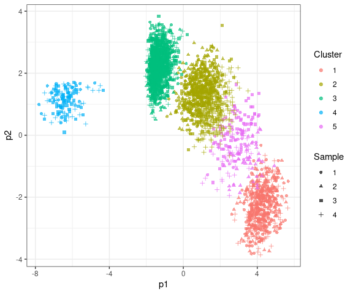

```r
ggplot(Y_tb) +
  geom_point(aes(x = p1, y = p2, col = Cluster, shape = Sample), alpha = 0.7) +
  theme_bw()
```

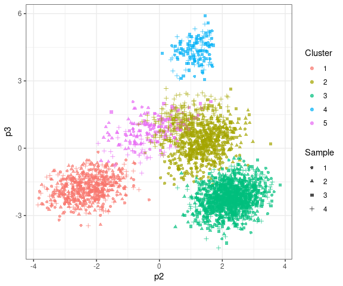

```r
ggplot(Y_tb) +
  geom_point(aes(x = p2, y = p3, col = Cluster, shape = Sample), alpha = 0.7) +
  theme_bw()
```

And then facet to show each cluster and sample separately.

$p_1$-$p_2$ margins:

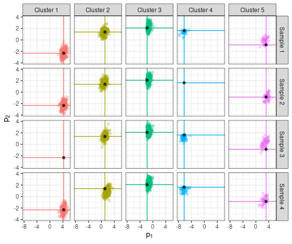

```r
ggplot(Y_tb) +
  geom_point(aes(x = p1, y = p2, col = Cluster), alpha = 0.25) +
  facet_grid(
    Sample ~ Cluster,
    labeller = labeller(Cluster = Cluster_names, Sample = Sample_names)
    ) +
  geom_hline(data = xi0_tb, aes(yintercept = p2, col = Cluster)) +
  geom_vline(data = xi0_tb, aes(xintercept = p1, col = Cluster)) +
  geom_point(data = xi0_tb, aes(x = p1, y = p2), alpha = 0.7) +
  xlab(expression(p[1])) +
  ylab(expression(p[2])) +
  theme_bw() +
  theme(legend.position = "none")
```

$p_2$-$p_3$ margins:

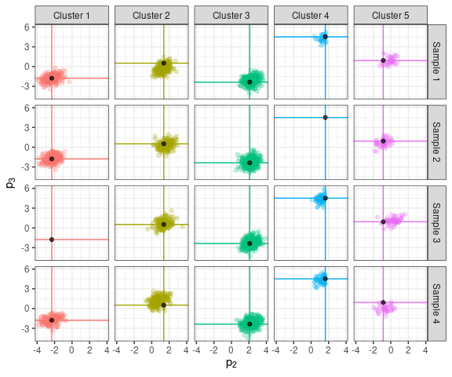

```r
ggplot(Y_tb) +
  geom_point(aes(x = p2, y = p3, col = Cluster), alpha = 0.25) +
  facet_grid(
    Sample ~ Cluster,
    labeller = labeller(Cluster = Cluster_names, Sample = Sample_names)
  ) +
  geom_hline(data = xi0_tb, aes(yintercept = p3, col = Cluster)) +
  geom_vline(data = xi0_tb, aes(xintercept = p2, col = Cluster)) +
  geom_point(data = xi0_tb, aes(x = p2, y = p3), alpha = 0.7) +
  xlab(expression(p[2])) +
  ylab(expression(p[3])) +
  theme_bw() +
  theme(legend.position = "none")
```

We can see that clusters 1, 3, and 4 are aligned well, whereas clusters 2 and 5 are misaligned, as can be assessed from the deviation of the clusters from their grand locations (black dots).

## Fitting the model

The maximal number of clusters, $K$, should be chosen to exceed the expected number of clusters in the data. Since the algorithm is expected to merge clusters during the first iterations, we recommend setting a burn-in period of at least several hundreds iterations.

And so, a reasonable attempt at a first fit for our data could be:

```r
set.seed(1)
prior <- list(zeta = 1, K = 10)
```

Where $\zeta$ is a coarsening parameter (to be discussed in a following section) and $K$ the maximal number of clusters.

```r
pmc <- list(npart = 10, nburn = 250, nsave = 250)
```

`npart` is the number of particles in the Population Monte Carlo chain. More particles increase the accuracy of the estimated parameters, at the cost of more computations (and memory requirements). 10 is a reasonable amount to start with, which can be chosen larger based on post-hoc analyses of the initial setting.

Fit the model:

```r
res <- comix(Y, C, pmc = pmc, prior = prior)
```

```
## initializing all particles...
## Done
## Merged clusters (iteration 5)
## Merged clusters (iteration 8)
## Merged clusters (iteration 17)
## Merged clusters (iteration 42)
## Iteration: 100 of 500
## Iteration: 200 of 500
## Iteration: 300 of 500
## Iteration: 400 of 500
## Iteration: 500 of 500
```

Since the MCMC chain may result with spurious label changes, it is recommended to run the function `relabelChain()` on the output to reduce potential problems:

```r
resRelab <- relabelChain(res)
```

```
## K=10
## T=250
## N=3000
## J=4
## p=3
```

The `res` and `resRelab` objects contain the full MCMC chains. To compute posterior point estimates for the different parameters, use:

```r
res_summary <- summarizeChain(resRelab)
```

Then, for instance, we can tabulate the estimated cluster labels by sample:

```r
t(table(res_summary$t, C))
```

```
##
## C     1   2   4   5   6
##   1 210  30 200  40 290
##   2 190   0 219  51 340
##   3 182  60   0  58 340
##   4 240  50 150  40 310
```

Since we know the true cluster labels we can compare the estimates to those:

```r
n_jk
```

```
##         Cluster1 Cluster2 Cluster3 Cluster4 Cluster5
## Sample1      200      210      290       30       40
## Sample2      220      190      340        0       50
## Sample3        0      180      340       60       60
## Sample4      150      240      310       50       40
```

Indeed, the classification has matched nearly perfectly the true labels.

Next, we can calibrate the data given the model fit:

```r
calibrated_data <- calibrate(resRelab)
```

(for very large data sets, consider using `calibrateNoDist()` that stores less information)

And plot the calibrated results (with the estimated cluster labels) in comparison to the original data:

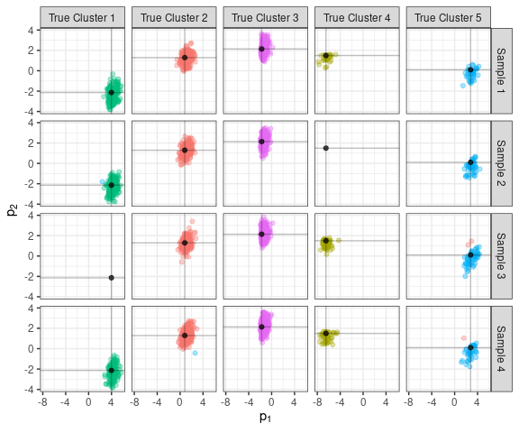

```r
Y_cal <- calibrated_data$Y_cal
colnames(Y_cal) <- paste0("p", 1:p, "_cal")
Y_tb <-
  bind_cols(
    Y_tb,
    as_tibble(Y_cal)
  )
Y_tb$Estimated_Cluster <- as.character(res_summary$t)

True_cluster_names <- paste("True Cluster", 1:K)
names(True_cluster_names) <- 1:K

non_trivial_clusters <- unique(Y_tb$Estimated_Cluster)

# Post-hoc manual mapping of estimated cluster labels
# to true cluster labels based on estimated sizes:
True_vs_Estimated_Cluster_Names <- c(1, 2, 3, 4, 5)
# (adjust the above line when running code for different model fits)

Estimated_Cluster_Labels <- as.integer(non_trivial_clusters)

estimated_xi0 <- t(res_summary$xi0[ , Estimated_Cluster_Labels])
colnames(estimated_xi0) <- paste0("p", 1:p, "_cal")
estimated_xi0_tb <-
  tibble(
    as_tibble(estimated_xi0),
    Estimated_Cluster = factor(Estimated_Cluster_Labels),
    Cluster = factor(True_vs_Estimated_Cluster_Names)
    )

ggplot(Y_tb) +
  geom_point(aes(x = p1_cal, y = p2_cal, col = Estimated_Cluster), alpha = 0.35) +
  facet_grid(
    Sample ~ Cluster,
    labeller = labeller(Cluster = True_cluster_names, Sample = Sample_names)
  ) +
  geom_hline(data = estimated_xi0_tb, aes(yintercept = p2_cal), col = "black", alpha = 0.25) +
  geom_vline(data = estimated_xi0_tb, aes(xintercept = p1_cal), col = "black", alpha = 0.25) +
  geom_point(data = estimated_xi0_tb, aes(x = p1_cal, y = p2_cal), alpha = 0.7) +
  xlab(expression(p[1])) +
  ylab(expression(p[2])) +
  theme_bw() +
  theme(legend.position = "none")
```

In the above plot the calibrated data are plotted. The intersection of the grey lines at the black circle denotes the estimated grand location cluster parameter. The columns are faceted by true cluster labels and the color coding corresponds to the estimated cluster labels. We can see the few points that were classified wrongly in Sample 4, True Cluster 2 and Samples 3 and 4, True Cluster 5. The calibrated data are indeed much better aligned in comparison to the original data.

## MCMC Diagnostics

The COMIX package includes several diagnostic functions to assess convergence of the MCMC chain.

- `effectiveSampleSize()` computes the effective sample sizes for each of the model parameters (based on the `effectiveSize()` function from the `coda` package), and `plotEffectiveSampleSize()` offers one possible visualization (different for each of the model parameters) to explore the results.
- `plotTracePlots()` generates trace plots for each of the model parameters.
- `heidelParams()` computes a test of stationarity of the MCMC chain, as well as a criterion of relative accuracy for the estimate of the mean (based on the `heidel.diag()` function from the `coda` package). `plotHeidelParams()` offers a visualuzation for these results.
- `gewekeParams()` computes a test for convergence of chains based on a test for equality of the means of the first and last part of a chain (based on the `geweke.diag()` function form the `coda` package). `plotGewekeParams()` offers a visualuzation for these results.
- `acfParams()` generates auto-correlation plots for the various parameters of the model (based on the `acf()` function).

The functions `effectiveSampleSize()`, `plotTracePlots()`, `heidelParams()`, `gewekeParams()` and `acfParams()` take as input either an object of class `COMIX` (a model fit or a relabeled model fit) or an object of class `tidyChainCOMIX`, resulting from `tidyChain` that applies to a `COMIX` object. In order to avoid running `tidyChain()` multiple times in the background, we first apply it to the relabeled results, store the output and use it as input for the diagnostic functions.

```r
tidy_chain <- tidyChain(resRelab)
```

Although the clusters are more intuitively parameterized by $\Sigma$, a scale matrix, and $\alpha$, a vector for skewness, the sampler generates posterior draws for the $G$ matrix and $\psi$ vector, which jointly provide an alternative parameterization for $\Sigma$ and $\alpha$. After the posterior estimates for $G$ and $\psi$ are computed, $\Sigma$ and $\alpha$ are computed from those. However, in order to evaluate the posterior’s distribution behavior and to assess convergence of the chain, the diagnostic functions are applied to $G$ and $\psi$.

### Trace plots

In order to plot trace plots of the posterior parameter estimate samples, use the `plotTracePlots()` function. Trace plots can be shown for each of the following parameters: `w`, the cluster- and sample- specific weights (denoted in the manuscript by $\omega_{j,k}$), `xi0` the grand location parameters `E` the variance-covariance matrix of the distribution from which the sample specific location parameters are drawn, `xi` the sample specific location parameters, `psi` and `G`, the parameters that jointly determine the scale and skewness of each of the clusters, and `eta`, a concentration parameter for the Griffiths-Engen-McCloskey (GEM) prior on the weights.

Show trace plots for the weights, where color coding corresponds to cluster (from 1 to $K$):

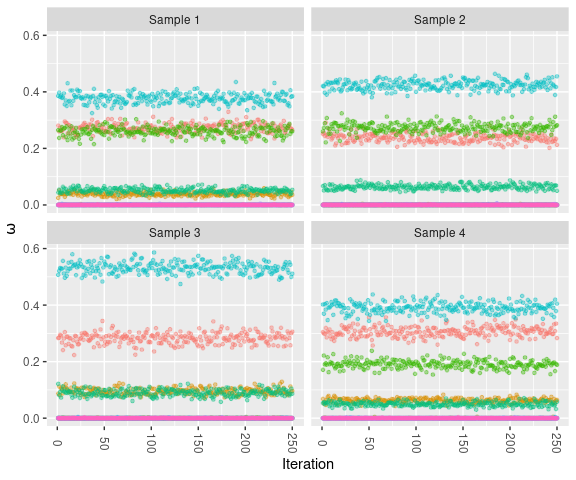

```r
plotTracePlots(tidy_chain, "w")
```

Show trace plots for the grand location parameters, where color coding corresponds to margin (from 1 to $p$):

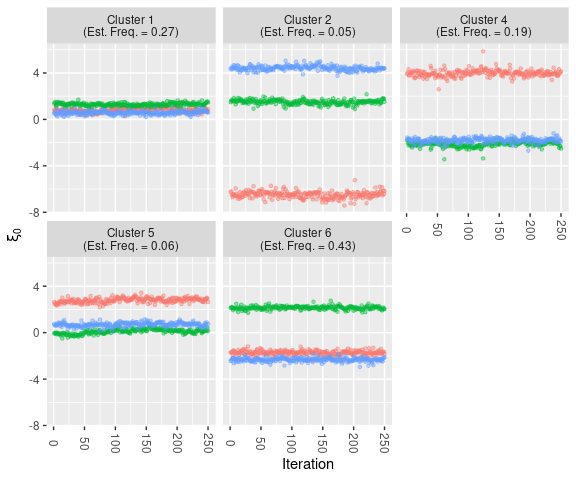

```r
plotTracePlots(tidy_chain, "xi0")
```

Trace plots for the sample specific location parameters, where color coding corresponds to margin (from 1 to $p$):

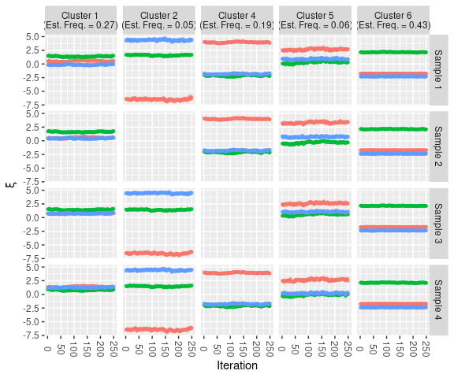

```r
plotTracePlots(tidy_chain, "xi")
```

Trace plots for the variance covariance matrix of the grand location parameters, where color coding corresponds to margin (from 1 to $p$):

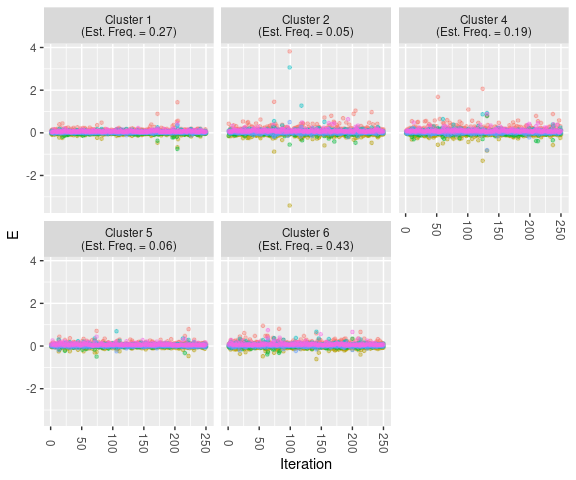

```r
plotTracePlots(tidy_chain, "E")
```

A trace plot for the parameter $\eta$ of the GEM process:

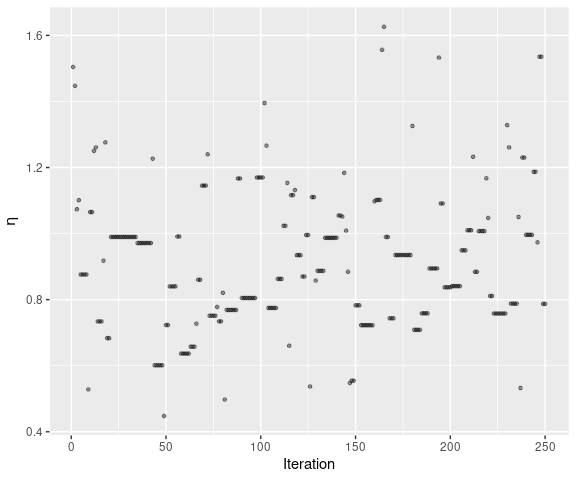

```r
plotTracePlots(tidy_chain, "eta")
```

The trace plots should converge to a single posterior estimate.

The above results suggest that the MCMC chain may be appropriate: the chains hover around constant values and do not switch to different estimates with large leaps. Such behavior suggests that the burn-in period is sufficiently long.

In contrast, the trace plots for the scale-skew parameters are less “well behaved”:

Trace plots for the scale-skew vector parameters:

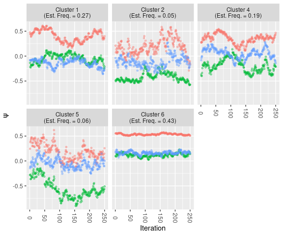

```r
plotTracePlots(tidy_chain, "psi")
```

Trace plots for the scale-skew matrix parameters:

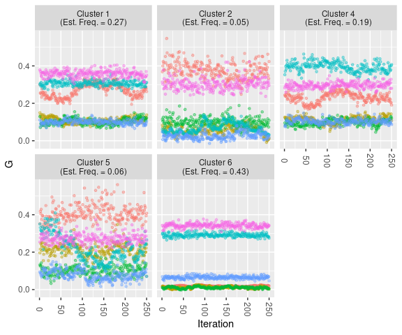

```r
plotTracePlots(tidy_chain, "G")
```

In general, the scale-skew parameters are harder to estimate. This is true especially for smaller clusters. Note how indeed the chains for clusters 2 and 5 (that correspond to smaller clusters, and can be seen in the title of each panel with the estimated frequency for each cluster) are spread more around the mean, providing lower accuracy for the posterior estimates. To stress, the wider spread does not indicate a problem with the chain, which may still sample well from the same posterior distribution, only that it has a larger estimated variance. In addition, bear in mind that estimating the scale-skew parameters is generally a task of secondary importance in comparison to the quality of calibration.

### Effective Sample Size

The Effective Sample Size is another popular method to evaluate the performance of MCMC chains. The function `effectiveSampleSize()` computes the effective sample size out of the total sample size as is given by `nsave`, the number of saved iterations of the chain after the burn in period (based on the `effectiveSize()` function from the `coda` package). The `effectiveSampleSize()` function returns an `effectiveSampleSizeCOMIX` object, which can be plotted with the function `plotEffectiveSampleSize()`. Examples:

```r
effssz <- effectiveSampleSize(tidy_chain)
```

The effective sample sizes for each group of parameters (e.g., all $\omega_{1,1},...,\omega_{j,k}$) are stored in a tidy data frame. For example, the effective sample sizes for the weight parameters:

```r
print(effssz$w, n = Inf)
```

```
## # A tibble: 40 × 5
##        k     j effssz triv          W
##    <int> <int>  <dbl> <lgl>     <dbl>
##  1     1     1   250  FALSE 0.272
##  2     2     1   348. FALSE 0.0387
##  3     3     1   250. TRUE  0.0000665
##  4     4     1   250  FALSE 0.260
##  5     5     1   250  FALSE 0.0514
##  6     6     1   332. FALSE 0.377
##  7     7     1   250. TRUE  0.000117
##  8     8     1   250  TRUE  0.000139
##  9     9     1   250  TRUE  0.0000797
## 10    10     1   250  TRUE  0.0000974
## 11     1     2   250  FALSE 0.238
## 12     2     2   250  TRUE  0.000106
```

[output cut: 28 more lines]

The column `k` refers to the cluster number, `j` to the sample, `effssz` to the effective sample size as computed by the `effectiveSize()` function from the `coda` package, `triv` is `TRUE` when no observations are classified in the posterior sample as being drawn from cluster `k`, and `FALSE` when the estimated number of observations in a cluster is greater than zero. `W` is the estimated weight for each sample and cluster.

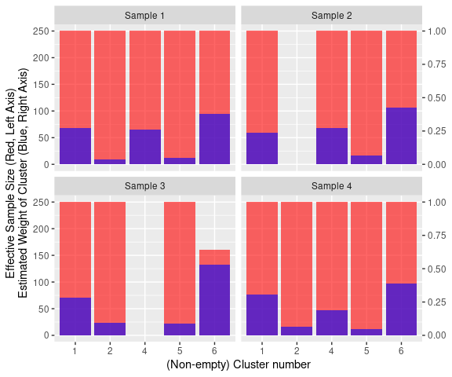

```r
plotEffectiveSampleSize(effssz, "w")
```

```r
print(effssz$w %>% filter(j == 3, k == 6))
```

```
## # A tibble: 1 × 5
##       k     j effssz triv      W
##   <int> <int>  <dbl> <lgl> <dbl>
## 1     6     3   161. FALSE 0.532
```

If the effective sample size is not very large, consider saving more iterations of the chain so to increase the accuracy of the estimated parameters.

As mentioned above, the COMIX package also provides functions that wrap popular functions from the `coda` package and offers some visualizations that provide a birds-eye view of those.

### Heidelberg-Welch convergence diagnostic

Heidelberg-Welch convergence diagnostic for the weights:

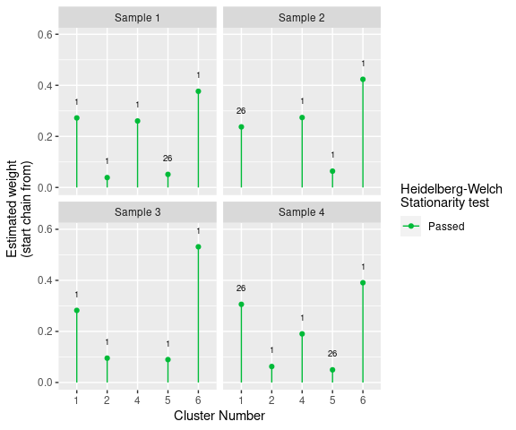

```r
tidy_chain %>%
  heidelParams("w") %>%
  plotHeidelParams("w")
```

The plots show the results from the Heidelberg-Welch convergence test for each of the $\omega_{j,k}$ parameters. The height of each line corresponds to the estimated weight size. The red/green color coding denotes whether or not the chain is stationary (“passed”) or not (“failed”). In addition, the integers in black near each line correspond to the `start` value as returned from the `heidel.diag()` function from the `coda` package: iterations before this figure should be discarded (and so 1 suggests that the full set of saved iterations can be used and considered a representative sample from a stationary chain).

### Geweke convergence diagnostic

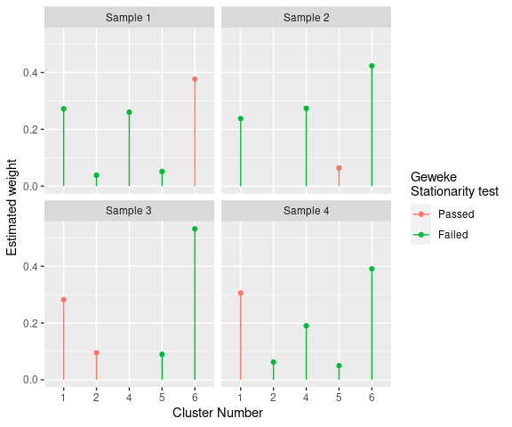

```r
tidy_chain %>%
  gewekeParams("w") %>%
  plotGewekeParams("w")
```

The plots show the results from the Geweke convergence test for each of the $\omega_{j,k}$ parameters. The height of each line corresponds to the estimated weight size. The red/green color coding denotes whether or not the chain is stationary (“passed”) or not (“failed”).

### Auto correlation plots

```r
acf_w <- acfParams(tidy_chain, params = "w", plot = FALSE)
```

The auto-correlation plots (not shown in the vignette due to lack of space) provide another assessment of the quality of the chain. If high auto-correlation persists, consider taking a longer burn in period and a larger number of iterations to save.

## Selecting the coarsening parameter

The COMIX generative model assumes that individual clusters are distributed according to a multivariate skew normal distribution. However, one of the main innovative features of the applied algorithm is its ability to incorporate “coarsening” into the model fitting procedure. Coarsening allows the cluster shapes to deviate from the theoretical multivariate skew normal kernels. The parameter that controls the amount of coarsesning is $\zeta$, a number between 0 and 1. When $\zeta$ is set to 1, the model is fit without any coarsening: clusters are fit as if they were distributed according to a multivariate skew normal distribution. The data in the example above were indeed generated from the multivariate skew normal distribution, and the fit was performed without coarsening (set with the parameter `zeta = 1` in the `prior` object). In the following, we will generate some 2 dimensional data from multivariate skew normal distributions, “distort” it so that the cluster shapes will deviate from the exact skew normal shapes, and demonstrate the algorithm’s performance with and without coarsening.

We start by drawing some data from exact bivariate skew normal for 3 clusters and 3 samples:

```r
set.seed(1)

# Three clusters:
K <- 3
k_names <- paste0("Cluster", 1:K)

# Three samples:
J <- 3
j_names <- paste0("Sample", 1:J)

# Dimension:
p <- 2
p_names <- paste0("p", 1:p)

# Number of observations per sample and cluster:
n_jk <-
  matrix(
    c(
      700, 600, 700,       # First row for the three clusters of the first sample
      720, 570, 720,       # Second row for the three clusters of the second sample
      680, 530, 780        # Third row for the three clusters of the third sample
      ),
    byrow = TRUE,
    nrow = 3,                    # Number of samples
    ncol = 3,                    # Number of clusters
    dimnames = list(j_names, k_names)
    )

print(n_jk)
```

```
##         Cluster1 Cluster2 Cluster3
## Sample1      700      600      700
## Sample2      720      570      720
## Sample3      680      530      780
```

```r
# Total number of observations:
(n <- sum(n_jk))
```

```
## [1] 6000
```

```r
# Grand cluster locations:
xi0 <-
  matrix(
    c(
       1,  10, 2,
      -1,  .5, 5
      ),
    byrow = TRUE,
    nrow = p,
    ncol = K
)
colnames(xi0) <- paste0("xi0,", 1:K)
rownames(xi0) <- p_names

print(xi0)
```

```
##    xi0,1 xi0,2 xi0,3
## p1     1  10.0     2
## p2    -1   0.5     5
```

```r
# Covariance of cluster locations around grand locations:
E <- list()

E[[1]] <- matrix(c(0.4, 0.04, 0.04, 0.3), nrow = 2, ncol = 2)
E[[2]] <- matrix(c(0.3, 0.03, 0.03, 0.3), nrow = 2, ncol = 2)
E[[3]] <- matrix(c(0.01, 0, 0, 0.01), nrow = 2, ncol = 2)

names(E) <- paste0("E", 1:K)
E <- lapply(E, function(e) {rownames(e) <- p_names; colnames(e) <- p_names; e})

xi <- NULL
for (k in 1:K) {
  xi <-
    bind_rows(
      xi,
      bind_cols(
        expand_grid(Sample = 1:J, Cluster = k),
        as_tibble(MASS::mvrnorm(J, xi0[ , k], E[[k]]))
        )
      )
}


# Set cluster scale parameter (same for all samples):
Sigma <- list()
Sigma[[1]] <- matrix(c(2, 0.5, 0.5, 1), nrow = 2, ncol = 2)
Sigma[[2]] <- matrix(c(1, 0.5, 0.5, 1), nrow = 2, ncol = 2)
Sigma[[3]] <- matrix(c(2, 0.5, 0.5, 1), nrow = 2, ncol = 2)

# Set cluster skew parameter (same for all samples):
# alpha <- matrix(0, nrow = p, ncol = K, )
alpha <-
  matrix(
    c(
      -6, -7, 1,
       8,  5, 4
      ),
    byrow = TRUE,
    nrow = p,
    ncol = K,
    dimnames = list(p_names, k_names)
    )

print(alpha)
```

```
##    Cluster1 Cluster2 Cluster3
## p1       -6       -7        1
## p2        8        5        4
```

```r
# Compute transformed parameters:
psi_G <- list()
for (k in 1:K) {
  psi_G[[k]] <- COMIX::transform_params(Sigma[[k]], alpha[ , k])
}

# Draw the observations:
Y <- NULL
C <- NULL
t <- NULL
for (j in 1:J) {
  for (k in 1:K) {
    xi_jk <- xi %>% filter(Sample == j, Cluster == k) %>% select(all_of(p_names)) %>% unlist()
    Y <-
      rbind(
        Y,
        sn::rmsn(n_jk[j, k], xi = xi_jk, Sigma[[k]], alpha = alpha[ , k])
      )
    C <- c(C, rep(j, n_jk[j, k]))
    t <- c(t, rep(k, n_jk[j, k]))
  }
}

# Sanity check:
print(table(C, t))
```

```
##    t
## C     1   2   3
##   1 700 600 700
##   2 720 570 720
##   3 680 530 780
```

```r
print(n_jk)
```

```
##         Cluster1 Cluster2 Cluster3
## Sample1      700      600      700
## Sample2      720      570      720
## Sample3      680      530      780
```

```r
print(all(table(C, t) == n_jk))
```

```
## [1] TRUE
```

Next, we apply some polynomial transformations to the margins of the data so to create “distorted” clusters, which resemble but deviate from the multivariate skew normal distributions of the clusters:

```r
# Generate distorted data:
Y_distorted <- Y

for (j in 1:J) {
  # Distort first cluster in sample j:
  msk <- (t == 1 & C == j)
  temp <- Y[msk ,]
  min_x <- min(temp[ , 1])
  max_x <- max(temp[ , 1])
  min_y <- min(temp[ , 2])
  max_y <- max(temp[ , 2])

  temp[ , 1] <- temp[ , 1] - min_x
  temp[ , 2] <- temp[ , 2] - min_y

  a <- 0.02

  temp[ , 2] <- temp[ , 2] * ( - a * temp[ , 1] ^ 2 + a * (max_x - min_x + 4) * temp[ , 1])
  temp[ , 1] <- temp[ , 1] + min_x
  temp[ , 2] <- temp[ , 2] + min_y

  Y_distorted[msk, ] <- temp

  # Distort second cluster in sample j:
  msk <- (t == 2 & C == j)
  temp <- Y[msk, ]

  min_x <- min(temp[ , 1])
  max_x <- max(temp[ , 1])
  min_y <- min(temp[ , 2])
  max_y <- max(temp[ , 2])

  temp[ , 1] <- temp[ , 1] - min_x
  temp[ , 2] <- temp[ , 2] - min_y

  a <- 0.06

  temp[ , 2] <- temp[ , 2] * ( - a * temp[ , 1] ^ 2 + a * (max_x - min_x + 2) * temp[ , 1])
  temp[ , 1] <- temp[ , 1] + min_x
  temp[ , 2] <- temp[ , 2] + min_y

  Y_distorted[msk, ] <- temp

  # Distort third cluster in sample j:
  msk <- (t == 3 & C == j)
  temp <- Y[msk ,]

  min_x <- min(temp[ , 1])
  max_x <- max(temp[ , 1])
  min_y <- min(temp[ , 2])
  max_y <- max(temp[ , 2])

  temp[ , 1] <- temp[ , 1] - min_x
  temp[ , 2] <- temp[ , 2] - min_y

  if (j==1) a = 0.025
  if (j==2 || j==3) a = 0.03

  temp[ , 2] <- temp[ , 2] * ( - a * temp[ , 1] ^ 2 + a * (max_x - min_x + 0.8) * temp[ , 1])
  temp[ , 1] <- temp[ , 1] + min_x
  temp[ , 2] <- temp[ , 2] + min_y
  Y_distorted[msk, ] <- temp
}

# Make tibbles and naming variables for plotting:
Y_tb <- Y
colnames(Y_tb) <- p_names
Y_tb <-
  bind_cols(
    tibble(Sample = factor(C), Cluster = factor(t)),
    as_tibble(Y_tb)
  )
Y_tb$Distorted <- FALSE

Y_distorted_tb <- Y_distorted
colnames(Y_distorted_tb) <- p_names
Y_distorted_tb <-
  bind_cols(
    tibble(Sample = factor(C), Cluster = factor(t)),
    as_tibble(Y_distorted_tb)
  )
Y_distorted_tb$Distorted <- TRUE

Y_all_tb <- bind_rows(Y_tb, Y_distorted_tb)
Y_all_tb$Distorted <- factor(Y_all_tb$Distorted)

xi0_tb <- as_tibble(t(xi0)) %>% mutate(Cluster = factor(1:K))

Sample_names <- paste("Sample", 1:J)
names(Sample_names) <- 1:J

Distorted_names <- c("Skew Normal", "Distorted")
names(Distorted_names) <- c(FALSE, TRUE)
```

Let’s get a sense of the data:

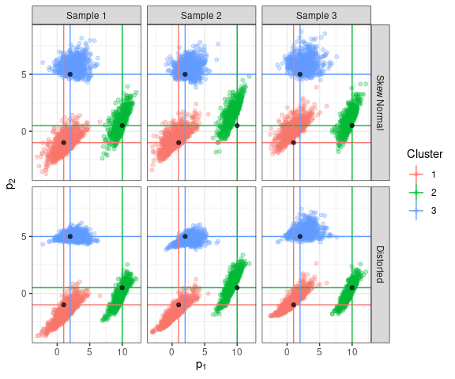

```r
ggplot(Y_all_tb) +
  geom_point(aes(x = p1, y = p2, col = Cluster), alpha = 0.3) +
  theme_bw() +
  facet_grid(
    Distorted ~ Sample,
    labeller = labeller(Sample = Sample_names, Distorted = Distorted_names)
    ) +
  geom_hline(data = xi0_tb, aes(yintercept = p2, col = Cluster)) +
  geom_vline(data = xi0_tb, aes(xintercept = p1, col = Cluster)) +
  geom_point(data = xi0_tb, aes(x = p1, y = p2), alpha = 0.7) +
  xlab(expression(p[1])) +
  ylab(expression(p[2]))
```

Let us fit the data twice: once without coarsening and once with $\zeta = 0.2$.

```r
no_coarsening_prior <- list(zeta = 1, K = 10)
coarsening_prior <- list(zeta = 0.2, K = 10)

pmc <- list(npart = 10, nburn = 1000, nsave = 250)

set.seed(1)
res_no_coarsening <- comix(Y_distorted, C, pmc = pmc, prior = no_coarsening_prior)
```

```
## initializing all particles...
## Done
## Merged clusters (iteration 10)
## Merged clusters (iteration 62)
## Merged clusters (iteration 83)
## Iteration: 100 of 1250
## Merged clusters (iteration 133)
## Iteration: 200 of 1250
## Merged clusters (iteration 241)
## Iteration: 300 of 1250
## Iteration: 400 of 1250
## Iteration: 500 of 1250
## Iteration: 600 of 1250
## Iteration: 700 of 1250
## Merged clusters (iteration 736)
## Merged clusters (iteration 772)
## Iteration: 800 of 1250
## Iteration: 900 of 1250
## Merged clusters (iteration 979)
## Iteration: 1000 of 1250
## Iteration: 1100 of 1250
## Iteration: 1200 of 1250
```

```r
set.seed(1)
res_coarsening <- comix(Y_distorted, C, pmc = pmc, prior = coarsening_prior)
```

```
## initializing all particles...
## Done
## Merged clusters (iteration 18)
## Merged clusters (iteration 22)
## Merged clusters (iteration 23)
## Merged clusters (iteration 28)
## Iteration: 100 of 1250
## Iteration: 200 of 1250
## Iteration: 300 of 1250
## Iteration: 400 of 1250
## Iteration: 500 of 1250
## Iteration: 600 of 1250
## Iteration: 700 of 1250
## Iteration: 800 of 1250
## Iteration: 900 of 1250
## Iteration: 1000 of 1250
## Iteration: 1100 of 1250
## Iteration: 1200 of 1250
```

```r
res_no_coarsening_Relab <- relabelChain(res_no_coarsening)
```

```
## K=10
## T=250
## N=6000
## J=3
## p=2
```

```r
res_coarsening_Relab <- relabelChain(res_coarsening)
```

```
## K=10
## T=250
## N=6000
## J=3
## p=2
```

The `res` and `resRelab` objects contain the full MCMC chains. To compute posterior point estimates for the different parameters, use:

```r
res_no_coarsening_summary <- summarizeChain(res_no_coarsening_Relab)
res_coarsening_summary <- summarizeChain(res_coarsening_Relab)
```

Then, for instance, we can tabulate the estimated cluster labels by sample:

```r
t(table(res_no_coarsening_summary$t, C))
```

```
##
## C     1   2   3   4   6  10
##   1 600 687 556   1 143  13
##   2 570 631 650   1  69  89
##   3 530 627 514   1 165 153
```

```r
t(table(res_coarsening_summary$t, C))
```

```
##
## C     1   5   6
##   1 600 700 700
##   2 570 720 720
##   3 530 780 680
```

Clearly, the coarsening manages to classify data correctly, while the model fit without coarsening breaks clusters into smaller ones.

Next, we can calibrate the data given the model fit and visually compare the results:

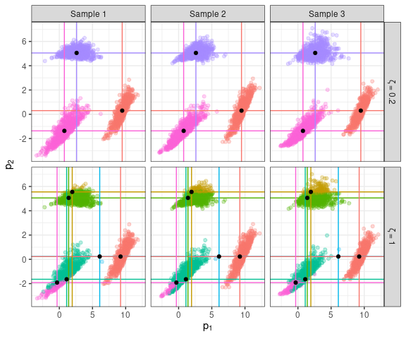

```r
calibrated_data_coarsening <- calibrate(res_coarsening_Relab)
Y_cal_coarsening <- calibrated_data_coarsening$Y_cal
colnames(Y_cal_coarsening) <- paste0("p", 1:p, "_cal")
Y_coarsening_tb <-
  bind_cols(
    Y_distorted_tb,
    as_tibble(Y_cal_coarsening)
  )
Y_coarsening_tb$Estimated_Cluster <- as.character(res_coarsening_summary$t)
Y_coarsening_tb$zeta <- "0.2"

calibrated_data_no_coarsening <- calibrate(res_no_coarsening_Relab)
Y_cal_no_coarsening <- calibrated_data_no_coarsening$Y_cal
colnames(Y_cal_no_coarsening) <- paste0("p", 1:p, "_cal")
Y_no_coarsening_tb <-
  bind_cols(
    Y_distorted_tb,
    as_tibble(Y_cal_no_coarsening)
  )
Y_no_coarsening_tb$Estimated_Cluster <- as.character(res_no_coarsening_summary$t)
Y_no_coarsening_tb$zeta <- "1"

Y_cal_tb <- bind_rows(Y_coarsening_tb, Y_no_coarsening_tb)

non_trivial_clusters_coarsening <- unique(Y_coarsening_tb$Estimated_Cluster)
non_trivial_clusters_no_coarsening <- unique(Y_no_coarsening_tb$Estimated_Cluster)

Estimated_Cluster_Labels_coarsening <- as.integer(non_trivial_clusters_coarsening)
Estimated_Cluster_Labels_no_coarsening <- as.integer(non_trivial_clusters_no_coarsening)

zeta_names <- c("\U03B6 = 0.2", "\U03B6 = 1")
names(zeta_names) <- c("0.2", "1")

estimated_xi0_coarsening <- t(res_coarsening_summary$xi0[ , Estimated_Cluster_Labels_coarsening])
colnames(estimated_xi0_coarsening) <- paste0("p", 1:p, "_cal")
estimated_xi0_coarsening_tb <-
  tibble(
    as_tibble(estimated_xi0_coarsening),
    Estimated_Cluster = non_trivial_clusters_coarsening
    )
estimated_xi0_coarsening_tb$zeta <- "0.2"

estimated_xi0_no_coarsening <-
  t(res_no_coarsening_summary$xi0[ , Estimated_Cluster_Labels_no_coarsening])
colnames(estimated_xi0_no_coarsening) <- paste0("p", 1:p, "_cal")
estimated_xi0_no_coarsening_tb <-
  tibble(
    as_tibble(estimated_xi0_no_coarsening),
    Estimated_Cluster = non_trivial_clusters_no_coarsening
    )
estimated_xi0_no_coarsening_tb$zeta <- "1"

estimated_xi0_tb <-
  bind_rows(estimated_xi0_coarsening_tb, estimated_xi0_no_coarsening_tb)

ggplot(Y_cal_tb) +
  geom_point(aes(x = p1_cal, y = p2_cal, col = Estimated_Cluster), alpha = 0.3) +
  facet_grid(
    zeta ~ Sample,
    labeller = labeller(zeta = zeta_names, Sample = Sample_names)
  ) +
  geom_hline(data = estimated_xi0_tb, aes(yintercept = p2_cal, col = Estimated_Cluster)) +
  geom_vline(data = estimated_xi0_tb, aes(xintercept = p1_cal, col = Estimated_Cluster)) +
  geom_point(data = estimated_xi0_tb, aes(x = p1_cal, y = p2_cal, group = Estimated_Cluster)) +
  xlab(expression(p[1])) +
  ylab(expression(p[2])) +
  theme_bw() +
  theme(legend.position = "none")
```

We can see that the model that was fitted with coarsening provides accurate classification and calibration. The model that was fitted without coarsening breaks the true clusters into smaller ones. Here, the calibration is minimally harmed by the misclassification, but this is not true in general. For further discussion and example of a sensitivity analysis geared towards choosing $\zeta$ see the manuscript.